# Phan tich Forest plot các ratio của left hand

Minh

2024-02-28

## Load bộ số liệu và các packages

## So sánh khác biệt về ratio của chỉ số Stress vs non stress theo các biến

Hàm để tạo bảng tổng hợp kết quả và p-value

Hàm sắp xếp các cột theo thứ tự

Hàm vẽ Forest plot

Bảng Stress index Ratio, level1 = “Yes”, level2 = “No”

|  | Variable | Subgroup | Level1_Mean | Level2_Mean | Ratio | CI_Lower | CI_Upper | P_Value |
| --- | --- | --- | --- | --- | --- | --- | --- | --- |
| M_left | M_left | Stress index | 26.5329762 | 21.2249240 | 1.2500858 | 1.0377458 | 1.5052099 | 0.0381952 |
| Kv100_left | Kv100_left | Stress index | 23.2055952 | 21.6257018 | 1.0730563 | 0.7788266 | 1.4383520 | 0.4640325 |
| δ_left | δ_left | Stress index | 5.3633333 | 3.7370117 | 1.4351931 | 1.1125549 | 1.8585804 | 0.0151978 |
| T_left | T_left | Stress index | 33.2104762 | 30.5827836 | 1.0859206 | 1.0422115 | 1.1306105 | 0.0169317 |
| A365_left | A365_left | Stress index | 100.7261905 | 85.9859649 | 1.1714259 | 0.8913623 | 1.4915418 | 0.3052460 |
| A460_left | A460_left | Stress index | 61.7738095 | 70.6625731 | 0.8742083 | 0.6986620 | 1.0903291 | 0.3025230 |
| Anadn_left | Anadn_left | Stress index | 1.1186905 | 1.2238012 | 0.9141113 | 0.4578957 | 1.6832017 | 0.0292591 |
| POM_left | POM_left | Stress index | 12.1683333 | 6.5017719 | 1.8715411 | 1.1954069 | 2.7455940 | 0.0127902 |
| A-E_left | A-E_left | Stress index | 1.8000000 | 1.5716491 | 1.1452938 | 0.8366809 | 1.5375692 | 0.2413602 |
| A-N_left | A-N_left | Stress index | 1.7666667 | 1.5111930 | 1.1690543 | 0.8388658 | 1.5486678 | 0.3052889 |
| A-M_left | A-M_left | Stress index | 1.4585714 | 1.1838889 | 1.2320172 | 0.9280663 | 1.5994158 | 0.0954401 |
| A-R_left | A-R_left | Stress index | 0.8763095 | 0.6624971 | 1.3227372 | 1.0180498 | 1.6956644 | 0.0654807 |
| A-C_left | A-C_left | Stress index | 1.0400000 | 0.9168363 | 1.1343356 | 0.9140275 | 1.4061066 | 0.2622852 |
| F-E_left | F-E_left | Stress index | 0.0151071 | 0.0152474 | 0.9908033 | 0.8923854 | 1.0978966 | 0.8339029 |
| F-N_left | F-N_left | Stress index | 0.0375357 | 0.0351193 | 1.0688059 | 0.9016212 | 1.2520520 | 0.3755210 |
| F-M_left | F-M_left | Stress index | 0.0696786 | 0.0802784 | 0.8679620 | 0.7784014 | 0.9772096 | 0.3806790 |
| F-R_left | F-R_left | Stress index | 0.3379762 | 0.3281532 | 1.0299341 | 0.8234763 | 1.2805524 | 0.5365367 |
| F-C_left | F-C_left | Stress index | 1.1246310 | 1.1385450 | 0.9877791 | 0.9034022 | 1.0776197 | 0.8124961 |

Forest plot cho Stress index ratio

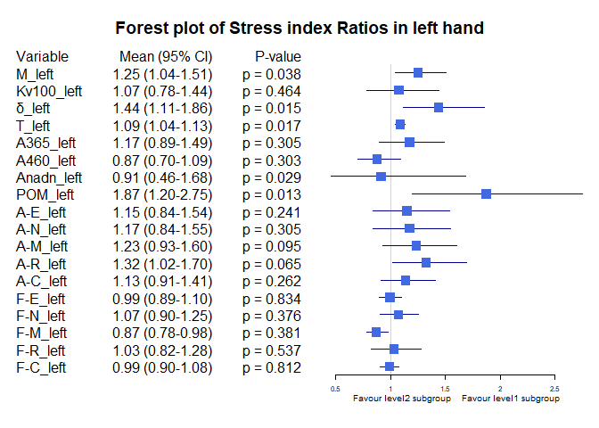

Bảng Gender Ratio, level1 = “male”, level2 = “female”

|  | Variable | Subgroup | Level1_Mean | Level2_Mean | Ratio | CI_Lower | CI_Upper | P_Value |
| --- | --- | --- | --- | --- | --- | --- | --- | --- |
| M_left | M_left | Gender | 23.9307185 | 20.9130556 | 1.1442957 | 0.9370498 | 1.4139304 | 0.1323960 |
| Kv100_left | Kv100_left | Gender | 18.3162593 | 27.1439646 | 0.6747820 | 0.5037759 | 0.8990008 | 0.0159219 |
| δ_left | δ_left | Gender | 3.8795852 | 4.5775253 | 0.8475290 | 0.6578076 | 1.0634357 | 0.1067077 |
| T_left | T_left | Gender | 31.0890074 | 31.5646465 | 0.9849313 | 0.9375318 | 1.0359140 | 0.9034010 |
| A365_left | A365_left | Gender | 89.1674074 | 91.0277778 | 0.9795626 | 0.7886697 | 1.2314737 | 0.8396801 |
| A460_left | A460_left | Gender | 69.3800000 | 66.7550505 | 1.0393221 | 0.8566013 | 1.2496631 | 0.7847379 |
| Anadn_left | Anadn_left | Gender | 1.2203704 | 1.1615909 | 1.0506025 | 0.6320489 | 1.7887434 | 0.2406712 |
| POM_left | POM_left | Gender | 8.4865037 | 7.4013131 | 1.1466214 | 0.7858382 | 1.6446909 | 0.7248776 |
| A-E_left | A-E_left | Gender | 1.5963481 | 1.6832828 | 0.9483541 | 0.7134674 | 1.2093485 | 0.0767323 |
| A-N_left | A-N_left | Gender | 1.5505111 | 1.6201515 | 0.9570161 | 0.7187204 | 1.2487014 | 0.1318052 |
| A-M_left | A-M_left | Gender | 1.2201111 | 1.3092929 | 0.9318855 | 0.7118821 | 1.2085013 | 0.1552813 |
| A-R_left | A-R_left | Gender | 0.6804222 | 0.7741162 | 0.8789666 | 0.6893965 | 1.1155627 | 0.3093852 |
| A-C_left | A-C_left | Gender | 0.9295111 | 0.9779293 | 0.9504891 | 0.7896083 | 1.1938525 | 0.9395281 |
| F-E_left | F-E_left | Gender | 0.0152319 | 0.0151793 | 1.0034625 | 0.9055614 | 1.1100066 | 0.9432091 |
| F-N_left | F-N_left | Gender | 0.0370881 | 0.0339722 | 1.0917198 | 0.9530262 | 1.2539102 | 0.3697338 |
| F-M_left | F-M_left | Gender | 0.0748526 | 0.0809318 | 0.9248846 | 0.7914710 | 1.0874283 | 0.3818398 |
| F-R_left | F-R_left | Gender | 0.3482274 | 0.3070303 | 1.1341793 | 0.9404194 | 1.3785198 | 0.2241786 |
| F-C_left | F-C_left | Gender | 1.1402311 | 1.1273914 | 1.0113889 | 0.9337618 | 1.1015639 | 0.7686839 |

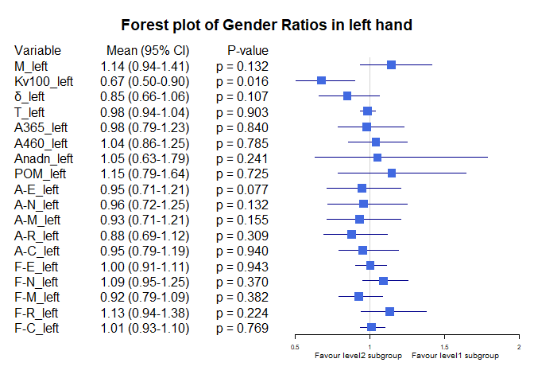

Bảng Smoking ratio, level1 = “Cigarettes, pipe tobacco…”, level2 = “Do not smoke”

|  | Variable | Subgroup | Level1_Mean | Level2_Mean | Ratio | CI_Lower | CI_Upper | P_Value |
| --- | --- | --- | --- | --- | --- | --- | --- | --- |
| M_left | M_left | Smoking | 21.8915476 | 22.8208047 | 0.9592803 | 0.6885858 | 1.2323560 | 0.9325537 |
| Kv100_left | Kv100_left | Smoking | 14.4630952 | 23.7109245 | 0.6099760 | 0.4409289 | 0.8278511 | 0.0187646 |
| δ_left | δ_left | Smoking | 3.2169048 | 4.3844219 | 0.7337124 | 0.4472048 | 1.1971721 | 0.0111169 |
| T_left | T_left | Smoking | 29.8427381 | 31.6068802 | 0.9441849 | 0.8573113 | 1.0244734 | 0.4385072 |
| A365_left | A365_left | Smoking | 84.9642857 | 91.0460938 | 0.9332008 | 0.6108336 | 1.2741493 | 0.7745059 |
| A460_left | A460_left | Smoking | 77.8095238 | 66.1825521 | 1.1756803 | 0.8278543 | 1.5769849 | 0.3972379 |
| Anadn_left | Anadn_left | Smoking | 2.0951190 | 0.9987109 | 2.0978233 | 0.8868856 | 4.0615962 | 0.0316690 |
| POM_left | POM_left | Smoking | 6.9844048 | 8.2555365 | 0.8460268 | 0.3151728 | 1.7379315 | 0.0332684 |
| A-E_left | A-E_left | Smoking | 1.0027381 | 1.7710260 | 0.5661905 | 0.2806897 | 0.9942754 | 0.0005204 |
| A-N_left | A-N_left | Smoking | 1.1322619 | 1.6779115 | 0.6748043 | 0.3720930 | 1.1125851 | 0.0082114 |
| A-M_left | A-M_left | Smoking | 0.8917857 | 1.3379167 | 0.6665480 | 0.3882834 | 1.0369103 | 0.0103100 |
| A-R_left | A-R_left | Smoking | 0.5769048 | 0.7513776 | 0.7677961 | 0.4854966 | 1.1733417 | 0.0598924 |
| A-C_left | A-C_left | Smoking | 0.7857143 | 0.9859323 | 0.7969252 | 0.6074516 | 1.0138650 | 0.1309024 |
| F-E_left | F-E_left | Smoking | 0.0161190 | 0.0150107 | 1.0738388 | 0.9508835 | 1.2006292 | 0.2383488 |
| F-N_left | F-N_left | Smoking | 0.0382262 | 0.0352326 | 1.0849680 | 0.8693023 | 1.3170304 | 0.4222905 |
| F-M_left | F-M_left | Smoking | 0.0796548 | 0.0769367 | 1.0353283 | 0.8456603 | 1.2749657 | 0.9156133 |
| F-R_left | F-R_left | Smoking | 0.4324524 | 0.3085609 | 1.4015137 | 1.1190784 | 1.7036889 | 0.0048527 |
| F-C_left | F-C_left | Smoking | 1.1975000 | 1.1210831 | 1.0681635 | 0.9806628 | 1.1713851 | 0.5181115 |

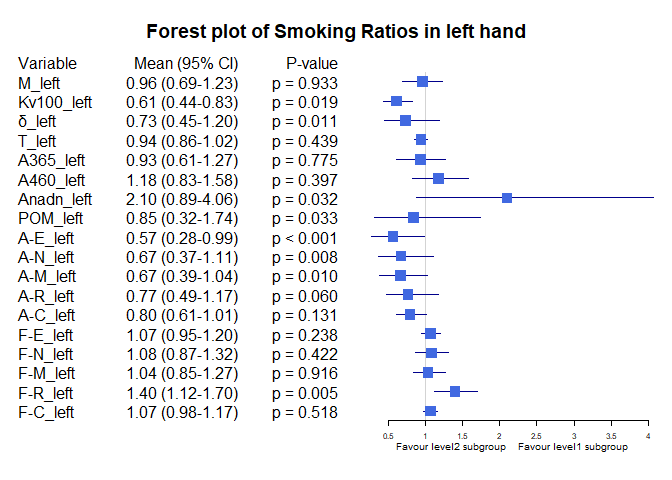

Bảng Smoking ratio, level1 = “Cigarettes, pipe tobacco…”, level2 = “Do not smoke”

|  | Variable | Subgroup | Level1_Mean | Level2_Mean | Ratio | CI_Lower | CI_Upper | P_Value |
| --- | --- | --- | --- | --- | --- | --- | --- | --- |
| M_left | M_left | Smoking | 21.8915476 | 22.8208047 | 0.9592803 | 0.7005197 | 1.2207911 | 0.9325537 |
| Kv100_left | Kv100_left | Smoking | 14.4630952 | 23.7109245 | 0.6099760 | 0.4472068 | 0.8103131 | 0.0187646 |
| δ_left | δ_left | Smoking | 3.2169048 | 4.3844219 | 0.7337124 | 0.4511057 | 1.1378471 | 0.0111169 |
| T_left | T_left | Smoking | 29.8427381 | 31.6068802 | 0.9441849 | 0.8582554 | 1.0349051 | 0.4385072 |
| A365_left | A365_left | Smoking | 84.9642857 | 91.0460938 | 0.9332008 | 0.6152794 | 1.2775625 | 0.7745059 |
| A460_left | A460_left | Smoking | 77.8095238 | 66.1825521 | 1.1756803 | 0.8653488 | 1.5502582 | 0.3972379 |
| Anadn_left | Anadn_left | Smoking | 2.0951190 | 0.9987109 | 2.0978233 | 0.8684509 | 3.8699259 | 0.0316690 |
| POM_left | POM_left | Smoking | 6.9844048 | 8.2555365 | 0.8460268 | 0.3160215 | 1.6400180 | 0.0332684 |
| A-E_left | A-E_left | Smoking | 1.0027381 | 1.7710260 | 0.5661905 | 0.2827449 | 1.0217614 | 0.0005204 |
| A-N_left | A-N_left | Smoking | 1.1322619 | 1.6779115 | 0.6748043 | 0.3494963 | 1.0789792 | 0.0082114 |
| A-M_left | A-M_left | Smoking | 0.8917857 | 1.3379167 | 0.6665480 | 0.3808410 | 1.0459654 | 0.0103100 |
| A-R_left | A-R_left | Smoking | 0.5769048 | 0.7513776 | 0.7677961 | 0.4806967 | 1.1610693 | 0.0598924 |
| A-C_left | A-C_left | Smoking | 0.7857143 | 0.9859323 | 0.7969252 | 0.6008621 | 1.0295247 | 0.1309024 |
| F-E_left | F-E_left | Smoking | 0.0161190 | 0.0150107 | 1.0738388 | 0.9485926 | 1.1949904 | 0.2383488 |
| F-N_left | F-N_left | Smoking | 0.0382262 | 0.0352326 | 1.0849680 | 0.8767466 | 1.3022108 | 0.4222905 |
| F-M_left | F-M_left | Smoking | 0.0796548 | 0.0769367 | 1.0353283 | 0.8403306 | 1.2673541 | 0.9156133 |
| F-R_left | F-R_left | Smoking | 0.4324524 | 0.3085609 | 1.4015137 | 1.1001345 | 1.7346213 | 0.0048527 |
| F-C_left | F-C_left | Smoking | 1.1975000 | 1.1210831 | 1.0681635 | 0.9824521 | 1.1773302 | 0.5181115 |

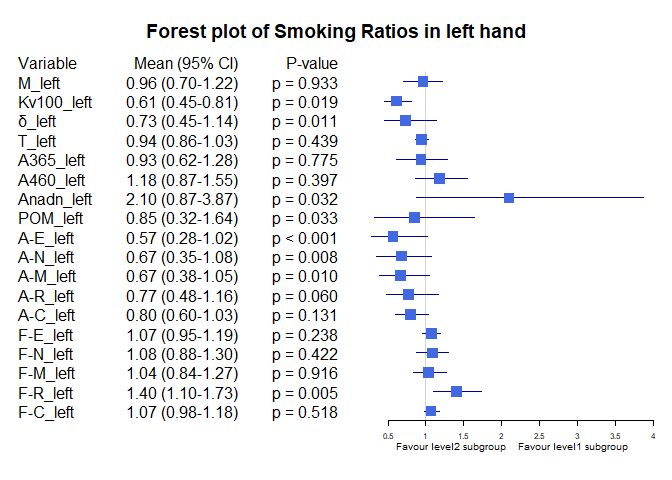

Bảng Hypertension ratio, level1 = “Yes”, level2 = “No”

|  | Variable | Subgroup | Level1_Mean | Level2_Mean | Ratio | CI_Lower | CI_Upper | P_Value |
| --- | --- | --- | --- | --- | --- | --- | --- | --- |
| M_left | M_left | Hypertension | 19.3701905 | 23.8638450 | 0.8116961 | 0.6157802 | 1.0093915 | 0.1525302 |
| Kv100_left | Kv100_left | Hypertension | 17.1088095 | 23.8718860 | 0.7166928 | 0.5290757 | 0.9448898 | 0.0788607 |
| δ_left | δ_left | Hypertension | 2.7376429 | 4.7043713 | 0.5819360 | 0.4329134 | 0.7542975 | 0.0001502 |
| T_left | T_left | Hypertension | 30.1820000 | 31.6985380 | 0.9521575 | 0.8851446 | 1.0172523 | 0.5848223 |
| A365_left | A365_left | Hypertension | 92.4023810 | 89.0526316 | 1.0376154 | 0.8221363 | 1.2709590 | 0.6975032 |
| A460_left | A460_left | Hypertension | 90.0523810 | 60.2441520 | 1.4947904 | 1.2171316 | 1.7943064 | 0.0005303 |
| Anadn_left | Anadn_left | Hypertension | 1.4952381 | 1.0850731 | 1.3780068 | 0.7696418 | 2.4071030 | 0.0238933 |
| POM_left | POM_left | Hypertension | 4.5186190 | 9.3200877 | 0.4848258 | 0.3174736 | 0.6987245 | 0.0046912 |
| A-E_left | A-E_left | Hypertension | 1.2172143 | 1.7863596 | 0.6813937 | 0.4562615 | 0.9739142 | 0.0107231 |
| A-N_left | A-N_left | Hypertension | 1.1918095 | 1.7229825 | 0.6917131 | 0.4247335 | 0.9903929 | 0.0073363 |
| A-M_left | A-M_left | Hypertension | 0.8741667 | 1.3991959 | 0.6247636 | 0.4222716 | 0.9088672 | 0.0013764 |
| A-R_left | A-R_left | Hypertension | 0.5069762 | 0.7985673 | 0.6348572 | 0.4498622 | 0.8746286 | 0.0008368 |
| A-C_left | A-C_left | Hypertension | 0.7010952 | 1.0416959 | 0.6730325 | 0.5250678 | 0.8435120 | 0.0013493 |
| F-E_left | F-E_left | Hypertension | 0.0150167 | 0.0152807 | 0.9827210 | 0.8817110 | 1.0947456 | 0.8162516 |
| F-N_left | F-N_left | Hypertension | 0.0342881 | 0.0363158 | 0.9441649 | 0.7767609 | 1.1461917 | 0.3096287 |
| F-M_left | F-M_left | Hypertension | 0.0767952 | 0.0776564 | 0.9889102 | 0.8345479 | 1.1917607 | 0.5862195 |
| F-R_left | F-R_left | Hypertension | 0.4015905 | 0.3047164 | 1.3179156 | 1.0630832 | 1.6004703 | 0.0145737 |
| F-C_left | F-C_left | Hypertension | 1.1843643 | 1.1165380 | 1.0607469 | 0.9745539 | 1.1636073 | 0.1203892 |

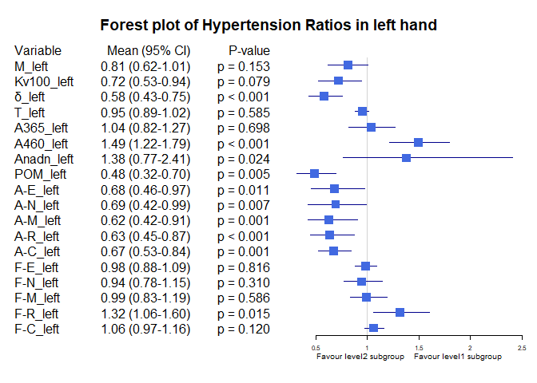

Bảng Obesity ratio, level1 = “Yes”, level2 = “No”

|  | Variable | Subgroup | Level1_Mean | Level2_Mean | Ratio | CI_Lower | CI_Upper | P_Value |
| --- | --- | --- | --- | --- | --- | --- | --- | --- |
| M_left | M_left | Obesity | 24.9205000 | 22.3949881 | 1.1127713 | 0.9512965 | 1.303755 | 0.7985078 |
| Kv100_left | Kv100_left | Obesity | 18.3239583 | 22.4770119 | 0.8152311 | 0.5775864 | 1.099077 | 0.6745039 |
| δ_left | δ_left | Obesity | 4.1008958 | 4.1833214 | 0.9802966 | 0.6924226 | 1.325866 | 0.9934296 |
| T_left | T_left | Obesity | 33.8190000 | 31.0012381 | 1.0908919 | 1.0413817 | 1.137800 | 0.0290921 |
| A365_left | A365_left | Obesity | 103.4937500 | 88.4071429 | 1.1706492 | 0.9747670 | 1.393124 | 0.3871657 |
| A460_left | A460_left | Obesity | 79.4916667 | 66.9869048 | 1.1866747 | 0.9105893 | 1.495148 | 0.2291222 |
| Anadn_left | Anadn_left | Obesity | 0.7810417 | 1.2428690 | 0.6284183 | 0.4457427 | 0.905630 | 0.7543171 |
| POM_left | POM_left | Obesity | 9.0665833 | 7.9086190 | 1.1464180 | 0.7863136 | 1.634532 | 0.1904215 |
| A-E_left | A-E_left | Obesity | 2.1062292 | 1.5790595 | 1.3338504 | 0.8989415 | 1.858195 | 0.1176623 |
| A-N_left | A-N_left | Obesity | 1.9180833 | 1.5413333 | 1.2444312 | 0.8479115 | 1.701059 | 0.1690470 |
| A-M_left | A-M_left | Obesity | 1.3817708 | 1.2436786 | 1.1110353 | 0.7768999 | 1.487910 | 0.3782057 |
| A-R_left | A-R_left | Obesity | 0.8185208 | 0.7088095 | 1.1547825 | 0.7744932 | 1.742010 | 0.7418405 |
| A-C_left | A-C_left | Obesity | 0.9882917 | 0.9456190 | 1.0451266 | 0.7970951 | 1.342360 | 0.6446500 |
| F-E_left | F-E_left | Obesity | 0.0145021 | 0.0152905 | 0.9484390 | 0.8400438 | 1.062635 | 0.5901680 |
| F-N_left | F-N_left | Obesity | 0.0346938 | 0.0358929 | 0.9665920 | 0.7899333 | 1.193456 | 0.9539350 |
| F-M_left | F-M_left | Obesity | 0.0744625 | 0.0777631 | 0.9575558 | 0.8137029 | 1.111687 | 0.6999858 |
| F-R_left | F-R_left | Obesity | 0.3489875 | 0.3287190 | 1.0616589 | 0.7586794 | 1.397447 | 0.4750510 |
| F-C_left | F-C_left | Obesity | 1.1851437 | 1.1290452 | 1.0496867 | 0.8812542 | 1.203874 | 0.2376917 |

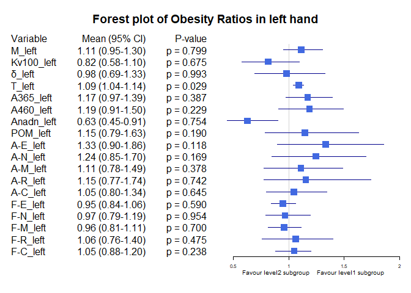

Bảng Race ratio, level1 = “White”, level2 = “Asian or Asian British”

|  | Variable | Subgroup | Level1_Mean | Level2_Mean | Ratio | CI_Lower | CI_Upper | P_Value |
| --- | --- | --- | --- | --- | --- | --- | --- | --- |
| M_left | M_left | Race | 27.8536190 | 21.1467623 | 1.3171576 | 1.1094341 | 1.5714588 | 0.0393984 |
| Kv100_left | Kv100_left | Race | 22.9898810 | 22.1756421 | 1.0367177 | 0.7530061 | 1.3993017 | 0.4504566 |
| δ_left | δ_left | Race | 5.9042619 | 3.7463934 | 1.5759855 | 1.2473729 | 1.9974874 | 0.0013638 |
| T_left | T_left | Race | 32.8872857 | 30.7787978 | 1.0685046 | 1.0223708 | 1.1164098 | 0.0674227 |
| A365_left | A365_left | Race | 109.9666667 | 89.4084699 | 1.2299357 | 0.9936573 | 1.5011742 | 0.1364576 |
| A460_left | A460_left | Race | 65.9476190 | 71.4877049 | 0.9225030 | 0.7729070 | 1.1133801 | 0.5957880 |
| Anadn_left | Anadn_left | Race | 0.6514286 | 1.2680191 | 0.5137372 | 0.3672775 | 0.7534891 | 0.0311295 |
| POM_left | POM_left | Race | 13.0690000 | 7.1229508 | 1.8347733 | 1.1984686 | 2.9443307 | 0.0010748 |
| A-E_left | A-E_left | Race | 2.6023095 | 1.4242896 | 1.8270930 | 1.3194638 | 2.4030803 | 0.0011545 |
| A-N_left | A-N_left | Race | 2.4465238 | 1.3666667 | 1.7901394 | 1.3384359 | 2.3207550 | 0.0005525 |
| A-M_left | A-M_left | Race | 1.8064286 | 1.1311749 | 1.5969490 | 1.2358202 | 2.0473304 | 0.0025372 |
| A-R_left | A-R_left | Race | 1.0215952 | 0.6497131 | 1.5723790 | 1.1388590 | 2.1415244 | 0.0183072 |
| A-C_left | A-C_left | Race | 1.2505714 | 0.8621585 | 1.4505123 | 1.1852647 | 1.7375011 | 0.0012988 |
| F-E_left | F-E_left | Race | 0.0144476 | 0.0153784 | 0.9394739 | 0.8314341 | 1.0539575 | 0.3484143 |
| F-N_left | F-N_left | Race | 0.0310214 | 0.0364713 | 0.8505707 | 0.7297132 | 0.9750517 | 0.2696869 |
| F-M_left | F-M_left | Race | 0.0700857 | 0.0798675 | 0.8775250 | 0.7706342 | 0.9914055 | 0.4436267 |
| F-R_left | F-R_left | Race | 0.2972786 | 0.3402678 | 0.8736607 | 0.6772834 | 1.1362054 | 0.5373888 |
| F-C_left | F-C_left | Race | 1.0605643 | 1.1524986 | 0.9202304 | 0.8133323 | 1.0145881 | 0.0896704 |

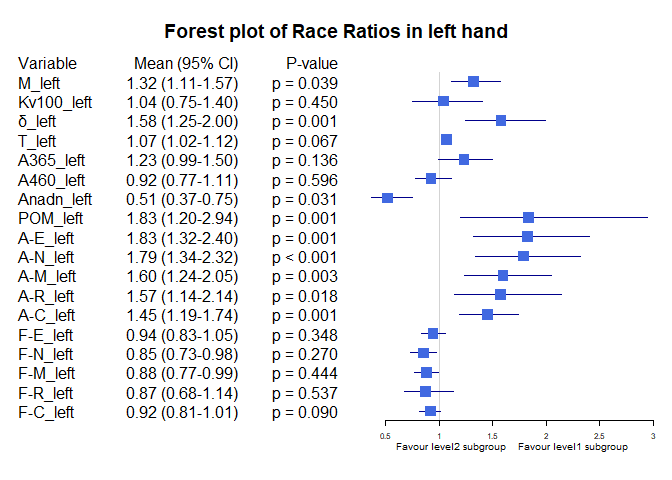

Bảng Race ratio, level1 = “Black, African, Caribbean or Black Bristish”, level2 = “Asian or Asian British”

|  | Variable | Subgroup | Level1_Mean | Level2_Mean | Ratio | CI_Lower | CI_Upper | P_Value |
| --- | --- | --- | --- | --- | --- | --- | --- | --- |
| M_left | M_left | Race | 29.0366667 | 21.1467623 | 1.3731022 | 1.1155652 | 1.6966289 | 0.2528587 |
| Kv100_left | Kv100_left | Race | 15.1366667 | 22.1756421 | 0.6825808 | 0.3200140 | 1.2430000 | 0.3738219 |
| δ_left | δ_left | Race | 4.8166667 | 3.7463934 | 1.2856809 | 0.5037447 | 2.5506760 | 0.9114818 |
| T_left | T_left | Race | 34.2366667 | 30.7787978 | 1.1123458 | 1.0627145 | 1.1648465 | 0.0834427 |
| A365_left | A365_left | Race | 7.6666667 | 89.4084699 | 0.0857488 | 0.0458943 | 0.1176767 | 0.0100790 |
| A460_left | A460_left | Race | 13.6666667 | 71.4877049 | 0.1911751 | 0.1615866 | 0.2294167 | 0.0051818 |
| Anadn_left | Anadn_left | Race | 2.2600000 | 1.2680191 | 1.7823075 | 0.8986840 | 3.1906665 | 0.0307771 |
| POM_left | POM_left | Race | 2.8900000 | 7.1229508 | 0.4057307 | 0.2718374 | 0.5821356 | 0.2039131 |
| A-E_left | A-E_left | Race | 1.3566667 | 1.4242896 | 0.9525216 | 0.2259312 | 1.7135769 | 0.8738127 |
| A-N_left | A-N_left | Race | 1.8733333 | 1.3666667 | 1.3707317 | 0.3689733 | 2.9402956 | 0.8738127 |
| A-M_left | A-M_left | Race | 1.2733333 | 1.1311749 | 1.1256733 | 0.4333230 | 2.1853951 | 1.0000000 |
| A-R_left | A-R_left | Race | 0.7433333 | 0.6497131 | 1.1440947 | 0.8336225 | 1.6207638 | 0.5047167 |
| A-C_left | A-C_left | Race | 1.3333333 | 0.8621585 | 1.5465061 | 0.8296826 | 2.2649838 | 0.1622014 |
| F-E_left | F-E_left | Race | 0.0153333 | 0.0153784 | 0.9970685 | 0.8543628 | 1.1186697 | 1.0000000 |
| F-N_left | F-N_left | Race | 0.0436667 | 0.0364713 | 1.1972881 | 0.8952367 | 1.5507254 | 0.2931407 |
| F-M_left | F-M_left | Race | 0.0620000 | 0.0798675 | 0.7762859 | 0.7039907 | 0.8507283 | 0.0957373 |
| F-R_left | F-R_left | Race | 0.2946667 | 0.3402678 | 0.8659847 | 0.5605103 | 1.3547750 | 0.4649379 |
| F-C_left | F-C_left | Race | 1.1213333 | 1.1524986 | 0.9729585 | 0.8838378 | 1.0754358 | 0.5239811 |

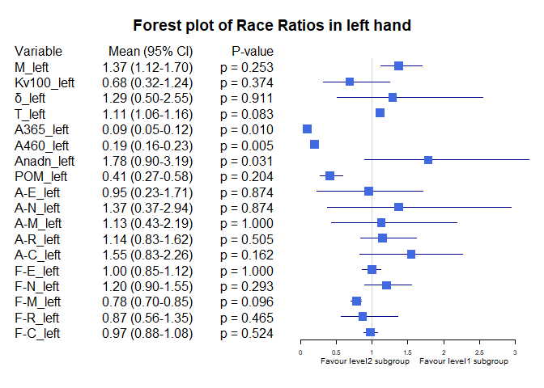

Bảng BMI ratio, level1 = “BMI <25”, level2 = “BMI [25-30)”

|  | Variable | Subgroup | Level1_Mean | Level2_Mean | Ratio | CI_Lower | CI_Upper | P_Value |
| --- | --- | --- | --- | --- | --- | --- | --- | --- |
| M_left | M_left | BMI_25_30 | 19.7088372 | 26.6729321 | 0.7389078 | 0.6061921 | 0.9025721 | 0.0102414 |
| Kv100_left | Kv100_left | BMI_25_30 | 23.9179457 | 20.1821914 | 1.1851015 | 0.8998362 | 1.6633334 | 0.2155310 |
| δ_left | δ_left | BMI_25_30 | 3.9666279 | 4.5284259 | 0.8759397 | 0.6663632 | 1.1270869 | 0.5030829 |
| T_left | T_left | BMI_25_30 | 30.1562016 | 32.3470370 | 0.9322709 | 0.8817233 | 0.9796036 | 0.0101706 |
| A365_left | A365_left | BMI_25_30 | 86.7713178 | 91.0123457 | 0.9534016 | 0.7485832 | 1.1907745 | 0.9711209 |
| A460_left | A460_left | BMI_25_30 | 66.6279070 | 67.5586420 | 0.9862233 | 0.7946572 | 1.2152682 | 0.6595313 |
| Anadn_left | Anadn_left | BMI_25_30 | 1.3906202 | 1.0075617 | 1.3801836 | 0.7940664 | 2.2287641 | 0.5422710 |
| POM_left | POM_left | BMI_25_30 | 6.8925581 | 9.5267901 | 0.7234922 | 0.4657476 | 1.1530268 | 0.0913001 |
| A-E_left | A-E_left | BMI_25_30 | 1.4784109 | 1.7393519 | 0.8499780 | 0.6051053 | 1.2014890 | 0.5423063 |
| A-N_left | A-N_left | BMI_25_30 | 1.4274806 | 1.7226543 | 0.8286518 | 0.5936846 | 1.1739051 | 0.5264218 |
| A-M_left | A-M_left | BMI_25_30 | 1.1816667 | 1.3424383 | 0.8802391 | 0.6666722 | 1.2198074 | 0.7491432 |
| A-R_left | A-R_left | BMI_25_30 | 0.6652326 | 0.7782099 | 0.8548241 | 0.6576858 | 1.1120764 | 0.2393953 |
| A-C_left | A-C_left | BMI_25_30 | 0.8831783 | 1.0450617 | 0.8450968 | 0.6928697 | 1.0485612 | 0.1409572 |
| F-E_left | F-E_left | BMI_25_30 | 0.0154380 | 0.0150556 | 1.0254012 | 0.9142748 | 1.1526484 | 0.6094959 |
| F-N_left | F-N_left | BMI_25_30 | 0.0354302 | 0.0366296 | 0.9672561 | 0.8205969 | 1.1339117 | 0.6986622 |
| F-M_left | F-M_left | BMI_25_30 | 0.0812132 | 0.0722685 | 1.1237698 | 0.9636692 | 1.3105821 | 0.6850343 |
| F-R_left | F-R_left | BMI_25_30 | 0.3131008 | 0.3535926 | 0.8854845 | 0.7203572 | 1.1020963 | 0.2698766 |
| F-C_left | F-C_left | BMI_25_30 | 1.1361202 | 1.1177778 | 1.0164097 | 0.9431017 | 1.1024256 | 0.9372716 |

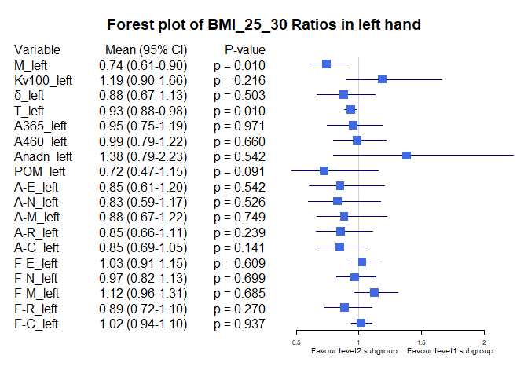

Bảng BMI ratio, level1 = “BMI >=30”, level2 = “BMI [25-30)”

|  | Variable | Subgroup | Level1_Mean | Level2_Mean | Ratio | CI_Lower | CI_Upper | P_Value |
| --- | --- | --- | --- | --- | --- | --- | --- | --- |
| M_left | M_left | BMI_25_30 | 24.9205000 | 26.6729321 | 0.9342992 | 0.7925715 | 1.118773 | 0.3631012 |
| Kv100_left | Kv100_left | BMI_25_30 | 18.3239583 | 20.1821914 | 0.9079271 | 0.6106293 | 1.302059 | 0.9539623 |
| δ_left | δ_left | BMI_25_30 | 4.1008958 | 4.5284259 | 0.9055897 | 0.6391349 | 1.237437 | 0.7433810 |
| T_left | T_left | BMI_25_30 | 33.8190000 | 32.3470370 | 1.0455053 | 1.0003259 | 1.096824 | 0.2207089 |
| A365_left | A365_left | BMI_25_30 | 103.4937500 | 91.0123457 | 1.1371397 | 0.9002461 | 1.458528 | 0.2977655 |
| A460_left | A460_left | BMI_25_30 | 79.4916667 | 67.5586420 | 1.1766321 | 0.8920436 | 1.525351 | 0.2625224 |
| Anadn_left | Anadn_left | BMI_25_30 | 0.7810417 | 1.0075617 | 0.7751800 | 0.5166668 | 1.156842 | 0.9530081 |
| POM_left | POM_left | BMI_25_30 | 9.0665833 | 9.5267901 | 0.9516934 | 0.6133441 | 1.551096 | 0.5760027 |
| A-E_left | A-E_left | BMI_25_30 | 2.1062292 | 1.7393519 | 1.2109276 | 0.7900441 | 1.829988 | 0.3070422 |
| A-N_left | A-N_left | BMI_25_30 | 1.9180833 | 1.7226543 | 1.1134464 | 0.7213278 | 1.656287 | 0.5425358 |
| A-M_left | A-M_left | BMI_25_30 | 1.3817708 | 1.3424383 | 1.0292993 | 0.7214272 | 1.482733 | 0.5556067 |
| A-R_left | A-R_left | BMI_25_30 | 0.8185208 | 0.7782099 | 1.0517996 | 0.6877066 | 1.659240 | 0.9217552 |
| A-C_left | A-C_left | BMI_25_30 | 0.9882917 | 1.0450617 | 0.9456778 | 0.7117705 | 1.237288 | 0.8751126 |
| F-E_left | F-E_left | BMI_25_30 | 0.0145021 | 0.0150556 | 0.9632380 | 0.8378767 | 1.108612 | 0.7975257 |
| F-N_left | F-N_left | BMI_25_30 | 0.0346938 | 0.0366296 | 0.9471499 | 0.7585824 | 1.200461 | 1.0000000 |
| F-M_left | F-M_left | BMI_25_30 | 0.0744625 | 0.0722685 | 1.0303587 | 0.8863435 | 1.201990 | 0.5373604 |
| F-R_left | F-R_left | BMI_25_30 | 0.3489875 | 0.3535926 | 0.9869763 | 0.7055047 | 1.347829 | 0.8874140 |
| F-C_left | F-C_left | BMI_25_30 | 1.1851437 | 1.1177778 | 1.0602678 | 0.8749797 | 1.219412 | 0.2145716 |

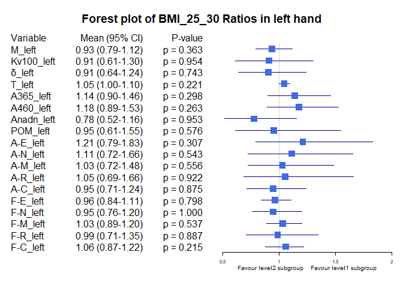

Bảng Age_stage ratio, level1 = “Age <30”, level2= “Age [30-40)”

|  | Variable | Subgroup | Level1_Mean | Level2_Mean | Ratio | CI_Lower | CI_Upper | P_Value |
| --- | --- | --- | --- | --- | --- | --- | --- | --- |
| M_left | M_left | Age_stage | 19.6532692 | 25.3512576 | 0.7752384 | 0.6006600 | 0.9893824 | 0.0947446 |
| Kv100_left | Kv100_left | Age_stage | 27.7751923 | 21.0282576 | 1.3208509 | 0.9736660 | 1.7645023 | 0.0831156 |
| δ_left | δ_left | Age_stage | 4.1582692 | 4.7532222 | 0.8748316 | 0.6771363 | 1.1233609 | 0.4619055 |
| T_left | T_left | Age_stage | 30.5000000 | 32.2822828 | 0.9447907 | 0.8939311 | 0.9979574 | 0.0225728 |
| A365_left | A365_left | Age_stage | 81.8461538 | 101.3772727 | 0.8073422 | 0.6030479 | 1.0360024 | 0.1533873 |
| A460_left | A460_left | Age_stage | 57.4038462 | 73.5106061 | 0.7808920 | 0.6246351 | 0.9640759 | 0.0573003 |
| Anadn_left | Anadn_left | Age_stage | 1.2288462 | 0.9086111 | 1.3524446 | 0.7571823 | 2.1916733 | 0.4271631 |
| POM_left | POM_left | Age_stage | 6.7784615 | 10.6032626 | 0.6392807 | 0.3959160 | 0.9899399 | 0.0440811 |
| A-E_left | A-E_left | Age_stage | 1.5325000 | 1.8803737 | 0.8149976 | 0.6159377 | 1.0814404 | 0.3247200 |
| A-N_left | A-N_left | Age_stage | 1.5180769 | 1.7583232 | 0.8633662 | 0.6315322 | 1.1507950 | 0.4636264 |
| A-M_left | A-M_left | Age_stage | 1.2450000 | 1.4193939 | 0.8771349 | 0.6621960 | 1.1511239 | 0.5669137 |
| A-R_left | A-R_left | Age_stage | 0.6946154 | 0.7821667 | 0.8880657 | 0.6901597 | 1.1480799 | 0.9939085 |
| A-C_left | A-C_left | Age_stage | 0.9665385 | 0.9807980 | 0.9854613 | 0.7806658 | 1.2483715 | 0.5824875 |
| F-E_left | F-E_left | Age_stage | 0.0154038 | 0.0150308 | 1.0248182 | 0.8972116 | 1.1555257 | 0.6434878 |
| F-N_left | F-N_left | Age_stage | 0.0377308 | 0.0336025 | 1.1228552 | 0.9418116 | 1.3165866 | 0.2383339 |
| F-M_left | F-M_left | Age_stage | 0.0802308 | 0.0736955 | 1.0886800 | 0.8999641 | 1.3074890 | 0.0731918 |
| F-R_left | F-R_left | Age_stage | 0.2706923 | 0.3277545 | 0.8258995 | 0.6566742 | 1.0324001 | 0.2601709 |
| F-C_left | F-C_left | Age_stage | 1.1316154 | 1.1591914 | 0.9762110 | 0.8891355 | 1.0687865 | 0.6903321 |

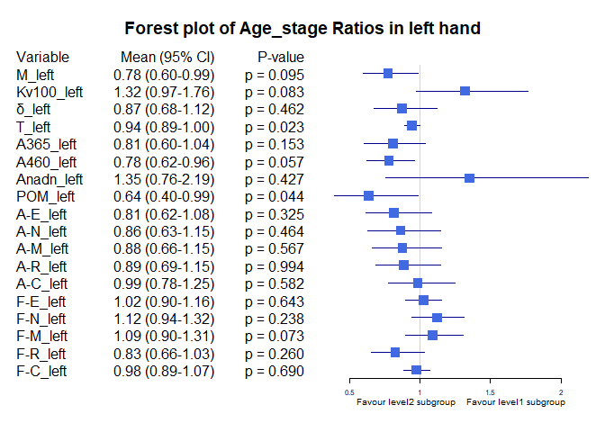

Bảng Age_stage ratio, level1 = “Age <30”, level2= “Age [40-50)”

|  | Variable | Subgroup | Level1_Mean | Level2_Mean | Ratio | CI_Lower | CI_Upper | P_Value |
| --- | --- | --- | --- | --- | --- | --- | --- | --- |
| M_left | M_left | Age_stage | 19.6532692 | 24.0101282 | 0.8185408 | 0.6022520 | 1.0955558 | 0.2428218 |
| Kv100_left | Kv100_left | Age_stage | 27.7751923 | 11.3402564 | 2.4492561 | 1.8105876 | 3.2169824 | 0.0000657 |
| δ_left | δ_left | Age_stage | 4.1582692 | 2.7820513 | 1.4946774 | 1.0590237 | 2.1483138 | 0.0356888 |
| T_left | T_left | Age_stage | 30.5000000 | 31.1891026 | 0.9779057 | 0.8999853 | 1.0826800 | 0.2809149 |
| A365_left | A365_left | Age_stage | 81.8461538 | 80.0384615 | 1.0225853 | 0.7030433 | 1.5911350 | 0.8464045 |
| A460_left | A460_left | Age_stage | 57.4038462 | 77.1794872 | 0.7437708 | 0.5334699 | 1.0729076 | 0.1524814 |
| Anadn_left | Anadn_left | Age_stage | 1.2288462 | 1.9470513 | 0.6311319 | 0.2891130 | 1.5846215 | 0.1285648 |
| POM_left | POM_left | Age_stage | 6.7784615 | 5.3755128 | 1.2609888 | 0.7798502 | 2.0961989 | 0.6066367 |
| A-E_left | A-E_left | Age_stage | 1.5325000 | 0.9714103 | 1.5776033 | 1.0273451 | 2.4669373 | 0.0226473 |
| A-N_left | A-N_left | Age_stage | 1.5180769 | 1.1316667 | 1.3414524 | 0.8712126 | 2.3598320 | 0.0762595 |
| A-M_left | A-M_left | Age_stage | 1.2450000 | 0.8626923 | 1.4431565 | 0.9398748 | 2.2973336 | 0.0584661 |
| A-R_left | A-R_left | Age_stage | 0.6946154 | 0.5543590 | 1.2530065 | 0.9090906 | 1.8162013 | 0.1526476 |
| A-C_left | A-C_left | Age_stage | 0.9665385 | 0.7846154 | 1.2318627 | 0.8994534 | 1.7348207 | 0.2702054 |
| F-E_left | F-E_left | Age_stage | 0.0154038 | 0.0156667 | 0.9832242 | 0.8739063 | 1.1099309 | 0.7523730 |
| F-N_left | F-N_left | Age_stage | 0.0377308 | 0.0356282 | 1.0590140 | 0.8459115 | 1.3050664 | 0.8578466 |
| F-M_left | F-M_left | Age_stage | 0.0802308 | 0.0798590 | 1.0046556 | 0.7896527 | 1.2433985 | 0.9759451 |
| F-R_left | F-R_left | Age_stage | 0.2706923 | 0.4342564 | 0.6233467 | 0.4927321 | 0.8174165 | 0.0015399 |
| F-C_left | F-C_left | Age_stage | 1.1316154 | 1.1445385 | 0.9887089 | 0.8889722 | 1.1040199 | 0.9048055 |

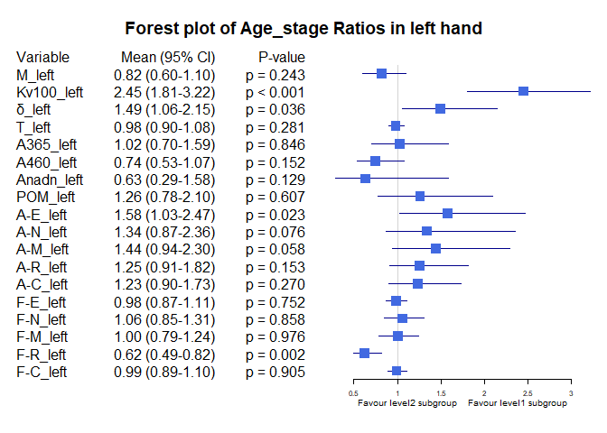

Bảng Age_stage ratio, level1 = “Age <30”, level2= “Age >=50”

|  | Variable | Subgroup | Level1_Mean | Level2_Mean | Ratio | CI_Lower | CI_Upper | P_Value |
| --- | --- | --- | --- | --- | --- | --- | --- | --- |
| M_left | M_left | Age_stage | 19.6532692 | 17.8841667 | 1.0989200 | 0.7187726 | 1.9666540 | 0.6890791 |
| Kv100_left | Kv100_left | Age_stage | 27.7751923 | 26.0786111 | 1.0650564 | 0.6498005 | 2.0201440 | 0.7597551 |
| δ_left | δ_left | Age_stage | 4.1582692 | 4.0836111 | 1.0182824 | 0.6359650 | 1.9413291 | 0.8468497 |
| T_left | T_left | Age_stage | 30.5000000 | 29.4775000 | 1.0346875 | 0.9119717 | 1.1938243 | 0.7353676 |
| A365_left | A365_left | Age_stage | 81.8461538 | 83.7500000 | 0.9772675 | 0.6159687 | 1.8201904 | 0.8468358 |
| A460_left | A460_left | Age_stage | 57.4038462 | 67.2222222 | 0.8539415 | 0.5816339 | 1.3917966 | 0.6119978 |
| Anadn_left | Anadn_left | Age_stage | 1.2288462 | 1.0005556 | 1.2281638 | 0.6981253 | 2.1083668 | 0.3587502 |
| POM_left | POM_left | Age_stage | 6.7784615 | 5.0177778 | 1.3508891 | 0.7649338 | 2.8527809 | 0.5878909 |
| A-E_left | A-E_left | Age_stage | 1.5325000 | 2.1430556 | 0.7151005 | 0.3866338 | 2.1122927 | 0.9422618 |
| A-N_left | A-N_left | Age_stage | 1.5180769 | 1.8386111 | 0.8256650 | 0.4715678 | 2.3863540 | 0.9812380 |
| A-M_left | A-M_left | Age_stage | 1.2450000 | 1.2811111 | 0.9718127 | 0.5845535 | 2.2382390 | 1.0000000 |
| A-R_left | A-R_left | Age_stage | 0.6946154 | 0.8477778 | 0.8193366 | 0.5029608 | 1.5561660 | 0.6814968 |
| A-C_left | A-C_left | Age_stage | 0.9665385 | 1.0672222 | 0.9056581 | 0.6784752 | 1.2467140 | 0.3222080 |
| F-E_left | F-E_left | Age_stage | 0.0154038 | 0.0143611 | 1.0726082 | 0.9139306 | 1.2753057 | 0.6086915 |
| F-N_left | F-N_left | Age_stage | 0.0377308 | 0.0395000 | 0.9552093 | 0.7191072 | 1.3207605 | 0.8653458 |
| F-M_left | F-M_left | Age_stage | 0.0802308 | 0.0805000 | 0.9966555 | 0.7568656 | 1.3607701 | 0.8636657 |
| F-R_left | F-R_left | Age_stage | 0.2706923 | 0.3838333 | 0.7052340 | 0.5346034 | 0.9379117 | 0.0116064 |
| F-C_left | F-C_left | Age_stage | 1.1316154 | 0.9933333 | 1.1392101 | 0.9361505 | 1.4115347 | 0.1830244 |

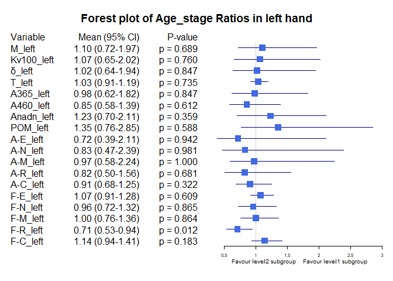

Bảng Age_stage ratio, level1 = “Age [30-40)”, level2= “Age >=50”

|  | Variable | Subgroup | Level1_Mean | Level2_Mean | Ratio | CI_Lower | CI_Upper | P_Value |
| --- | --- | --- | --- | --- | --- | --- | --- | --- |
| M_left | M_left | Age_stage | 25.3512576 | 17.8841667 | 1.4175252 | 1.0004907 | 2.461100 | 0.1167429 |
| Kv100_left | Kv100_left | Age_stage | 21.0282576 | 26.0786111 | 0.8063412 | 0.4945900 | 1.545650 | 0.6901766 |
| δ_left | δ_left | Age_stage | 4.7532222 | 4.0836111 | 1.1639752 | 0.7425853 | 2.308216 | 0.4576410 |
| T_left | T_left | Age_stage | 32.2822828 | 29.4775000 | 1.0951500 | 0.9794618 | 1.252138 | 0.3297433 |
| A365_left | A365_left | Age_stage | 101.3772727 | 83.7500000 | 1.2104749 | 0.8189185 | 2.107952 | 0.5991709 |
| A460_left | A460_left | Age_stage | 73.5106061 | 67.2222222 | 1.0935462 | 0.7606397 | 1.792785 | 0.6970625 |
| Anadn_left | Anadn_left | Age_stage | 0.9086111 | 1.0005556 | 0.9081066 | 0.6003274 | 1.396888 | 0.2931974 |
| POM_left | POM_left | Age_stage | 10.6032626 | 5.0177778 | 2.1131391 | 1.2430597 | 4.527776 | 0.0832962 |
| A-E_left | A-E_left | Age_stage | 1.8803737 | 2.1430556 | 0.8774265 | 0.4805539 | 2.593419 | 0.8052411 |
| A-N_left | A-N_left | Age_stage | 1.7583232 | 1.8386111 | 0.9563323 | 0.5510252 | 2.347679 | 0.5992264 |
| A-M_left | A-M_left | Age_stage | 1.4193939 | 1.2811111 | 1.1079398 | 0.6446355 | 2.477593 | 0.5080836 |
| A-R_left | A-R_left | Age_stage | 0.7821667 | 0.8477778 | 0.9226081 | 0.5584415 | 1.866580 | 0.7115133 |
| A-C_left | A-C_left | Age_stage | 0.9807980 | 1.0672222 | 0.9190195 | 0.7217998 | 1.228700 | 0.5205978 |
| F-E_left | F-E_left | Age_stage | 0.0150308 | 0.0143611 | 1.0466327 | 0.9017640 | 1.234889 | 0.7391402 |
| F-N_left | F-N_left | Age_stage | 0.0336025 | 0.0395000 | 0.8506968 | 0.6361290 | 1.158597 | 0.4238355 |
| F-M_left | F-M_left | Age_stage | 0.0736955 | 0.0805000 | 0.9154715 | 0.7029949 | 1.199265 | 0.6753826 |
| F-R_left | F-R_left | Age_stage | 0.3277545 | 0.3838333 | 0.8538981 | 0.6360936 | 1.134176 | 0.1674034 |
| F-C_left | F-C_left | Age_stage | 1.1591914 | 0.9933333 | 1.1669712 | 0.9727955 | 1.429828 | 0.1050057 |

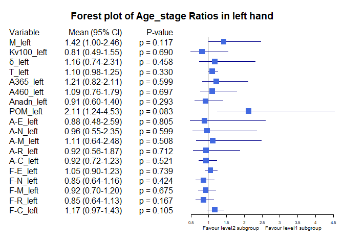

Bảng Age_stage ratio, level1 = “Age [30-40)”, level2= “Age [40-50)”

|  | Variable | Subgroup | Level1_Mean | Level2_Mean | Ratio | CI_Lower | CI_Upper | P_Value |
| --- | --- | --- | --- | --- | --- | --- | --- | --- |
| M_left | M_left | Age_stage | 25.3512576 | 24.0101282 | 1.0558568 | 0.8632087 | 1.3513686 | 1.0000000 |
| Kv100_left | Kv100_left | Age_stage | 21.0282576 | 11.3402564 | 1.8543018 | 1.4068551 | 2.4206889 | 0.0040611 |
| δ_left | δ_left | Age_stage | 4.7532222 | 2.7820513 | 1.7085315 | 1.2194123 | 2.5023235 | 0.0067689 |
| T_left | T_left | Age_stage | 32.2822828 | 31.1891026 | 1.0350501 | 0.9616785 | 1.1302768 | 0.8661278 |
| A365_left | A365_left | Age_stage | 101.3772727 | 80.0384615 | 1.2666070 | 0.9497222 | 1.8378011 | 0.2366468 |
| A460_left | A460_left | Age_stage | 73.5106061 | 77.1794872 | 0.9524630 | 0.7228523 | 1.3158823 | 0.8836011 |
| Anadn_left | Anadn_left | Age_stage | 0.9086111 | 1.9470513 | 0.4666601 | 0.2337268 | 1.1295456 | 0.0247976 |
| POM_left | POM_left | Age_stage | 10.6032626 | 5.3755128 | 1.9725118 | 1.2371394 | 3.4491311 | 0.0250855 |
| A-E_left | A-E_left | Age_stage | 1.8803737 | 0.9714103 | 1.9357153 | 1.3137957 | 3.1011598 | 0.0044793 |
| A-N_left | A-N_left | Age_stage | 1.7583232 | 1.1316667 | 1.5537466 | 1.0119425 | 2.5996685 | 0.0392494 |
| A-M_left | A-M_left | Age_stage | 1.4193939 | 0.8626923 | 1.6453073 | 1.1205219 | 2.7134232 | 0.0185526 |
| A-R_left | A-R_left | Age_stage | 0.7821667 | 0.5543590 | 1.4109389 | 1.0037489 | 2.0186293 | 0.1570192 |
| A-C_left | A-C_left | Age_stage | 0.9807980 | 0.7846154 | 1.2500366 | 0.9378613 | 1.7212053 | 0.1958968 |
| F-E_left | F-E_left | Age_stage | 0.0150308 | 0.0156667 | 0.9594133 | 0.8513793 | 1.0806128 | 0.5400278 |
| F-N_left | F-N_left | Age_stage | 0.0336025 | 0.0356282 | 0.9431439 | 0.7664007 | 1.1798780 | 0.4707260 |
| F-M_left | F-M_left | Age_stage | 0.0736955 | 0.0798590 | 0.9228199 | 0.7310770 | 1.1482949 | 0.2330594 |
| F-R_left | F-R_left | Age_stage | 0.3277545 | 0.4342564 | 0.7547489 | 0.6040819 | 0.9640666 | 0.0484207 |
| F-C_left | F-C_left | Age_stage | 1.1591914 | 1.1445385 | 1.0128025 | 0.9126482 | 1.1301933 | 0.4925891 |

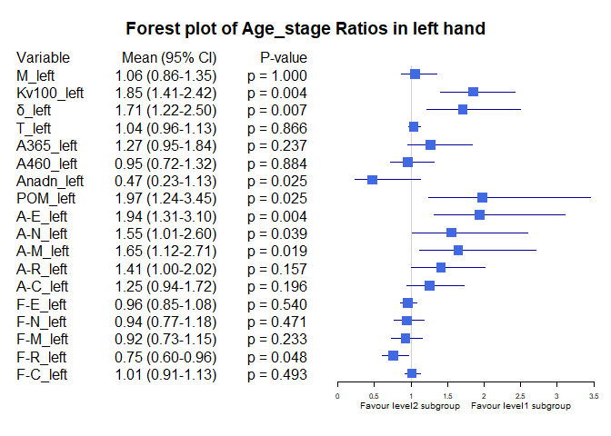

Bảng Age_stage ratio, level1 = “Age [40-50)”, level2= “Age >=50”

|  | Variable | Subgroup | Level1_Mean | Level2_Mean | Ratio | CI_Lower | CI_Upper | P_Value |
| --- | --- | --- | --- | --- | --- | --- | --- | --- |
| M_left | M_left | Age_stage | 24.0101282 | 17.8841667 | 1.3425355 | 0.8830161 | 2.479768 | 0.1791243 |
| Kv100_left | Kv100_left | Age_stage | 11.3402564 | 26.0786111 | 0.4348489 | 0.2672199 | 0.833042 | 0.0364883 |
| δ_left | δ_left | Age_stage | 2.7820513 | 4.0836111 | 0.6812723 | 0.4010002 | 1.376432 | 0.6293843 |
| T_left | T_left | Age_stage | 31.1891026 | 29.4775000 | 1.0580647 | 0.9121454 | 1.223708 | 0.7653693 |
| A365_left | A365_left | Age_stage | 80.0384615 | 83.7500000 | 0.9556831 | 0.5661942 | 1.845091 | 0.9300493 |
| A460_left | A460_left | Age_stage | 77.1794872 | 67.2222222 | 1.1481246 | 0.7353976 | 1.896252 | 0.4819372 |
| Anadn_left | Anadn_left | Age_stage | 1.9470513 | 1.0005556 | 1.9459702 | 0.8273523 | 3.921784 | 0.8314168 |
| POM_left | POM_left | Age_stage | 5.3755128 | 5.0177778 | 1.0712935 | 0.5624864 | 2.410721 | 0.9660917 |
| A-E_left | A-E_left | Age_stage | 0.9714103 | 2.1430556 | 0.4532828 | 0.2102579 | 1.564224 | 0.6929541 |
| A-N_left | A-N_left | Age_stage | 1.1316667 | 1.8386111 | 0.6155008 | 0.3088835 | 1.683444 | 0.6388029 |
| A-M_left | A-M_left | Age_stage | 0.8626923 | 1.2811111 | 0.6733938 | 0.3570724 | 1.654667 | 0.5788737 |
| A-R_left | A-R_left | Age_stage | 0.5543590 | 0.8477778 | 0.6538966 | 0.3763004 | 1.333265 | 0.2361962 |
| A-C_left | A-C_left | Age_stage | 0.7846154 | 1.0672222 | 0.7351940 | 0.5063910 | 1.044207 | 0.1043795 |
| F-E_left | F-E_left | Age_stage | 0.0156667 | 0.0143611 | 1.0909091 | 0.9347105 | 1.290557 | 0.2701890 |
| F-N_left | F-N_left | Age_stage | 0.0356282 | 0.0395000 | 0.9019799 | 0.6761290 | 1.258551 | 0.5089936 |
| F-M_left | F-M_left | Age_stage | 0.0798590 | 0.0805000 | 0.9920369 | 0.7392118 | 1.355451 | 0.8247722 |
| F-R_left | F-R_left | Age_stage | 0.4342564 | 0.3838333 | 1.1313671 | 0.8436244 | 1.545581 | 0.4483050 |
| F-C_left | F-C_left | Age_stage | 1.1445385 | 0.9933333 | 1.1522199 | 0.9479757 | 1.445116 | 0.1588750 |

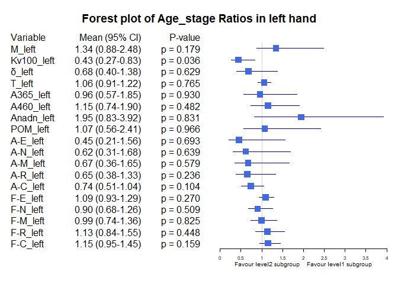